# Model evaluation and selection

# 1 Required packages

```r
# install.packages(c("corrplot", "doRNG", "dplyr", "forecast", "GA", "ggplot2", "glmmTMB", "knitr", "memoise", "MuMIn", "parallel", "patchwork", "tidyr"))

library(corrplot)
library(doRNG)
library(dplyr)
library(forecast)
library(GA)
library(ggplot2)
library(glmmTMB)
library(knitr)
library(memoise)
library(MuMIn)
library(parallel)
library(patchwork)
library(tidyr)
```

# 2 Introduction

Considerations when choosing a “best” model:

- **We want a model that fits the observed data well**
- **We want a model that makes biological sense**
  - Includes plausible covariates, even if the precise mechanism is not known
- **We want a model that can make good predictions (in the future)**
  - Especially important in MSE context where forecasts are run
  - There may be special considerations when covariates extend beyond the observed range
- Metrics
  - Internal model metrics (AIC, LogLik)

# 3 Synthetic data creation

We will generate the data used in the example for simplicity and to gain insight into the model selection process, as we will know the “true” underlying relationship. The example shown here will be to fit an environmentally-mediated stock-recruitment relationship (EMSRR), using a modified Ricker (“controlling”-type as described by Levi et al. 2003)

## 3.1 Environmental covariates

First we define some environmental covariates using an autoregressive integrated moving average (ARIMA) model. Here we will model only AR1 processes, which is the degree of correlation of subsequent values based on prior values.

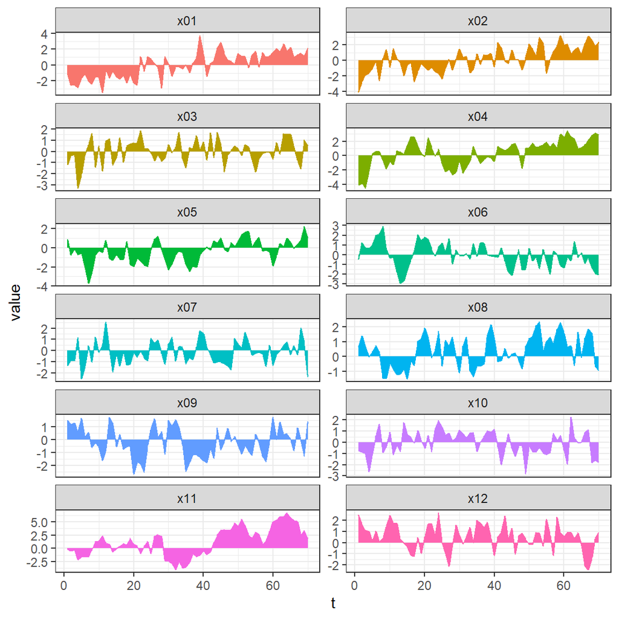

```r
set.seed(1235)
n <- 70
ncov <- 12
AR <- runif(ncov, min = 0, max = 0.9) # auto-regression coefficients

envvars <- paste0("x", formatC(x = seq(ncov), digits = 1, flag = 0))
tmp <- lapply(seq(ncov), FUN = function(i){
  # Generate the time series
  ts_data <- arima.sim(model = list(ar = AR[i]), n = n)
  return(ts_data)
})

tmp <- as.data.frame(matrix(unlist(tmp), nrow = n, ncol = ncov))
names(tmp) <- envvars
dat <- cbind(data.frame(t = seq(n)), tmp)

# add a trend to x01 and x02
dat$x01 <- dat$x01 + diff(range(dat$x01))*0.01*(dat$t-mean(dat$t)) # 1% of sd per year
dat$x02 <- dat$x02 + diff(range(dat$x02))*0.01*(dat$t-mean(dat$t)) # 1% of sd per year

# plot time series
df <- tidyr::pivot_longer(dat, cols = seq(ncol(dat))[-1])
ggplot(df) + aes(x = t, y = value, fill = name, color = name) +
  geom_area(show.legend = F) +
  facet_wrap(~ name, ncol = 2, scales = "free_y") +
  theme_bw()
```

## 3.2 Biological covariates and response

Generate ssb and rec

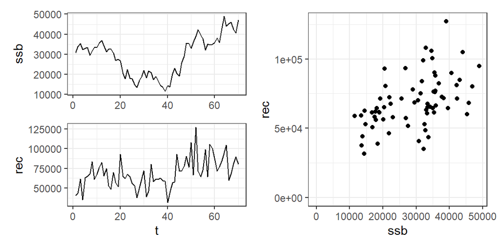

```r
# generate ssb (random walk)
set.seed(236)
dat$ssb <- 30000 - cumsum(rnorm(n, 0, 3000))

# generate recruitment (Ricker model + env mediation from x01 & x03)
dat$rec <- exp(log(5) + log(dat$ssb) - 2.5e-5*dat$ssb + 0.05*dat$x01 + 0.05*dat$x03)
dat$rec <- dat$rec * rlnorm(n, 0, 0.2) # additional random noise

p1 <- ggplot(dat) + aes(x = t, y = ssb) +
  geom_line()
p2 <- ggplot(dat) + aes(x = t, y = rec) +
  geom_line()
p3 <- ggplot(dat) + aes(x = ssb, y = rec) +
  geom_point() +
  lims(x = c(0, NA), y = c(0, NA))

layout <- "
AC
BC
"
p <- p1 + p2 + p3 + plot_layout(design = layout, axis_titles = "collect") &
  theme_bw()
p
```

## 3.3 Resulting correlations among variables

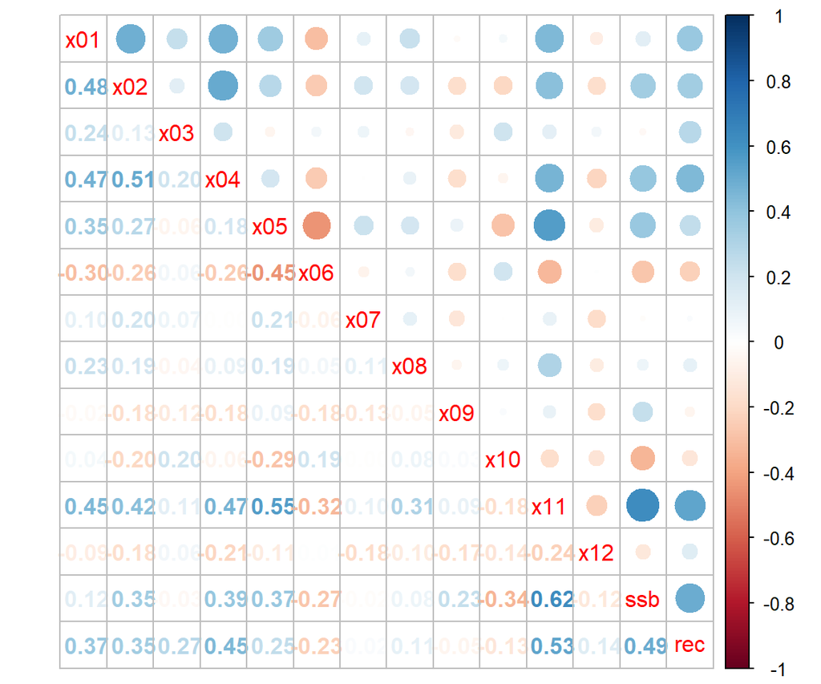

```r
corrplot.mixed(cor(dat[,-1]))
```

## 3.4 Full model definition

Ricker with (Levi et al. 2003; Iles and Beverton 1998; Akimova et al. 2016; Iles 1994)

Concept of penalization (degrees of freedom)

ANOVA comparison (`summary`) - single term drops

```r
fmla <- formula(paste(c("rec ~ offset(log(ssb)) + ssb", envvars), collapse = " + "))
fmla
```

```
## rec ~ offset(log(ssb)) + ssb + x01 + x02 + x03 + x04 + x05 +
##     x06 + x07 + x08 + x09 + x10 + x11 + x12
```

```r
fit0 <- glm(fmla, data = dat, family = gaussian(link = "log"))
summary(fit0)
```

```
##
## Call:
## glm(formula = fmla, family = gaussian(link = "log"), data = dat)
##
## Coefficients:
##               Estimate Std. Error t value Pr(>|t|)
## (Intercept)  1.627e+00  1.211e-01  13.435  < 2e-16 ***
## ssb         -2.712e-05  4.029e-06  -6.731 9.64e-09 ***
## x01          3.734e-02  2.257e-02   1.654   0.1036
## x02          1.110e-02  2.171e-02   0.511   0.6111
## x03          5.202e-02  2.645e-02   1.967   0.0542 .
## x04          7.466e-03  2.032e-02   0.367   0.7147
## x05         -9.060e-03  2.905e-02  -0.312   0.7563
## x06         -1.113e-02  2.481e-02  -0.448   0.6556
## x07          1.608e-02  2.521e-02   0.638   0.5262
## x08          1.345e-02  2.557e-02   0.526   0.6009
## x09         -2.467e-02  2.603e-02  -0.948   0.3474
## x10          9.328e-03  2.499e-02   0.373   0.7104
## x11          2.051e-02  1.568e-02   1.308   0.1961
## x12          5.378e-02  2.422e-02   2.220   0.0305 *
## ---
## Signif. codes:  0 '***' 0.001 '**' 0.01 '*' 0.05 '.' 0.1 ' ' 1
##
## (Dispersion parameter for gaussian family taken to be 199130548)
##
##     Null deviance: 3.0082e+10  on 69  degrees of freedom
## Residual deviance: 1.1151e+10  on 56  degrees of freedom
## AIC: 1550.7
##
## Number of Fisher Scoring iterations: 6
```

# 4 Model selection with Akaike information criterion

A large part of model building is selecting the best model to describe the response variable. An important concept to remember when looking for the “best” model is whether the addition of terms improves the predictive power of the model. Generally, the more explanatory variables that one has, the more variation will be explained in the response variable, but one has to be careful not to include variables that do not explain a *significant* portion of the variation. The inclusion of these terms might help you achieve a higher $R^2$ value for your specific data set, but are likely to be a poor predictor of new data that was not seen during the fitting. This problem is referred to as “*overfitting*”.

As a general rule, one should start by removing higher-order terms first (e.g. interaction terms) before moving on main terms or lower-level nested terms. Furthermore, some believe that there is a general rule stating that the main term should always be included if the term is also used in an interaction (see discussion [here](http://stats.stackexchange.com/q/11009/10675)).

This logic is within the automated stepwise search routine found in the function `step()` (introduced below), which usually makes sense, however it is definitely not a hard and fast rule. A basic guideline might be to try and formulate models are plausible given your specific question, and treat the inclusion of terms as hypotheses to be tested (see discussion [here](http://stats.stackexchange.com/q/4901/10675)).

## 4.1 Stepwise search

Let’s compare fit0 and fit with AIC and cross validation metrics

```r
# model with all original variables in fit0
all_variables <- "rec ~ ."
# Variables that should always be in the model (Ricker without env.)
fixed_variables <- "rec ~ offset(log(ssb)) + ssb"

fit <- step(fit0,
  scope = list(
    lower = as.formula(fixed_variables),
    upper = as.formula(all_variables)
  ),
  direction = "both",
  trace = FALSE # set to TRUE if you would like to see the model selections steps
)

summary(fit)
```

```
##
## Call:
## glm(formula = rec ~ ssb + x01 + x03 + x09 + x11 + x12 + offset(log(ssb)),
##     family = gaussian(link = "log"), data = dat)
##
## Coefficients:
##               Estimate Std. Error t value Pr(>|t|)
## (Intercept)  1.624e+00  1.001e-01  16.214  < 2e-16 ***
## ssb         -2.663e-05  3.431e-06  -7.762 9.29e-11 ***
## x01          4.595e-02  1.819e-02   2.526   0.0141 *
## x03          5.323e-02  2.373e-02   2.243   0.0284 *
## x09         -3.247e-02  2.218e-02  -1.464   0.1482
## x11          2.296e-02  1.398e-02   1.643   0.1054
## x12          4.543e-02  2.189e-02   2.075   0.0420 *
## ---
## Signif. codes:  0 '***' 0.001 '**' 0.01 '*' 0.05 '.' 0.1 ' ' 1
##
## (Dispersion parameter for gaussian family taken to be 182674743)
##
##     Null deviance: 3.0082e+10  on 69  degrees of freedom
## Residual deviance: 1.1509e+10  on 63  degrees of freedom
## AIC: 1538.9
##
## Number of Fisher Scoring iterations: 5
```

```r
c(fit0=AIC(fit0), fit=AIC(fit)) # comparison of AIC
```

```
##     fit0      fit
## 1550.694 1538.901
```

Akaike rule-of-thumb for improved model: $\delta AIC \geq 2$

## 4.2 Dredging

If your model fitting is fast, and there are not too many possible combinations ($combinations = 2^n-1$, where n is the number of possible covariaes), then one could try all possible models with the `dredge` function of the package `MuMIn` (*Multi-Model Inference*), which can handle many model types. In our example, it’s relatively quick to run through all model types. The function `pdredge` can also parallelize the process.

```r
fmla <- formula(paste(c("rec ~ offset(log(ssb)) + ssb", envvars), collapse = " + "))
# argument na.action = na.fail required for fair comparisons
fittmp <- glm(fmla, data = dat, family = gaussian(link = "log"), na.action = na.fail)

t1 <- Sys.time()
dd <- dredge(fittmp, fixed = c("offset(log(ssb))", "ssb"), trace = FALSE)
```

```
## Fixed terms are "offset(log(ssb))", "ssb" and "(Intercept)"
```

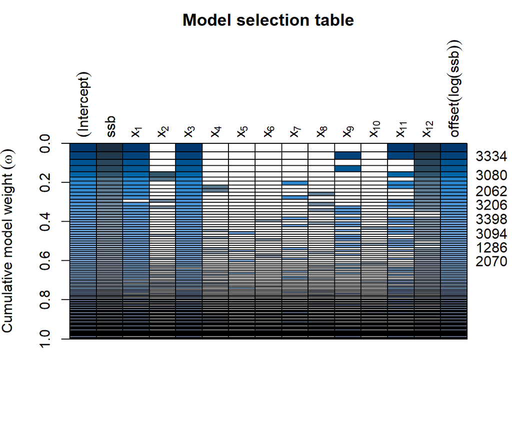

```r
t2 <- Sys.time()
# t2 - t1

# subset(dd[1:100,], delta < 4)
plot(dd[1:100,], labAsExpr = TRUE)
```

# 5 Visualizing marginal effects

One way to visualize the envitonmental covariate effects, is to hold all others at their median values, and generate a range of values only for a single focus covariate.

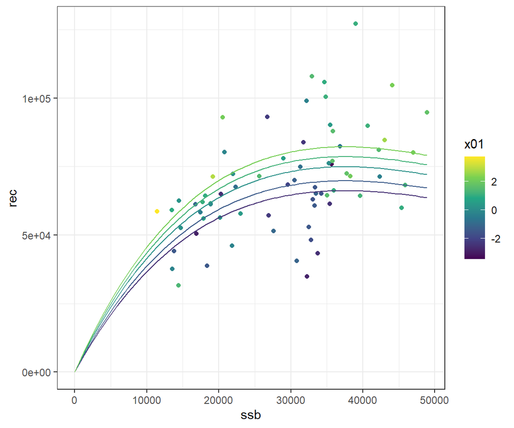

```r
envvarsKeep <- intersect(names(coef(fit)), envvars) # maintained env. covariates
# envvarsKeep <- c("x01", "x03")
focusVar <- envvarsKeep[1] # choose covariate of focus

## generate data for prediction
# focus covariate generated at 5 quantile levels, other env covariates use median
L <- lapply(envvarsKeep, FUN = function(x){
  if(x == focusVar){probs = c(0.05,0.25,0.5,0.75,0.95)}else{probs <- 0.5}
  quantile(dat[,x], probs = probs)
})
names(L) <- envvarsKeep
L[["ssb"]] <-  seq(0, max(dat$ssb), len = 100)

nd <- expand.grid(L)
nd$rec <- predict(fit, newdata = nd, type = "response")

ggplot(dat) + aes(x = ssb, y = rec, col = get(focusVar)) +
  geom_point() +
  scale_color_continuous(name = focusVar, type = "viridis") +
  geom_line(data = nd, mapping = aes(group = get(focusVar))) +
  theme_bw()
```

# 6 Model selection via cross validation

- Cross validation is a very flexible framework that tests how well a model can predict independent (unseen) data
- Data is typically split into two set; one for model fitting (*training data*) and one for prediction (*validation data*)
- Can be used as a basis for selecting best performing model (e.g. inclusion of terms, model structure) as it can evaluate overfitting
- Performance can be evaluated based on the desired metric

## 6.1 Common metrics

Note that these metrics may differ from those by the model’s fitting criteria to the training data set. Consistency between the two may be desirable, although one might want to emphasize other aspects of the prediction (validation) data set.

For example, squared error metrics, like Mean Squared Error ($MSE$) and Root Mean Squared Error ($RMSE$), will more heavily penalize outliers and large errors. Mean Absolute Error $MAE$ an intuitive metric that gives average error in the same units as the data. Mean Absolute Percentage Error ($MAPE$) and Mean Absolute Scaled Error ($MASE$) provide a scale-independent metric, useful when data varies significantly in magnitude.

Below are some R functions that can return these metrics, with arguments `y` and `yhat` providing the observed and predicted response values, respectively, of the validation data.

```r
# Mean Squared Error (MSE)
mse <- function(y, yhat){mean((y - yhat)^2, na.rm = TRUE)}

# Root Mean Squared Error (RMSE)
rmse <- function(y, yhat){sqrt(mean((y - yhat)^2, na.rm = TRUE))}

# Mean Absolute Percentage Error (MAPE)
mape <- function(y, yhat){mean(abs(y - yhat) / y, na.rm = TRUE)}

# Median Absolute Percentage Error (MAPE)
mdape <- function(y, yhat){median(abs(y - yhat) / y, na.rm = TRUE)}

# Mean Absolute Error (MAE)
mae <- function(y, yhat){mean(abs(y - yhat), na.rm = TRUE)}

# Mean Absolute Scaled Error (MASE)
mase <- function(y, yhat, yhat_naive){mean(abs(y - yhat), na.rm = TRUE) /
    mean(abs(y - yhat_naive), na.rm = TRUE)}
```

## 6.2 Flavor 1: Repeated k-fold

Many flavors of cross validation exist, but we will focus on one of the most common and flexible ones – *k-fold cross validation*.

In this approach, the *k* signifies the number of random groupings (i.e. *folds*) to use for the training and validation data. The groups are balanced, such that each data sample will be used once for validation.

For example, the commonly used 5-fold cross validation divides the data into 5 groups, with each fold using 4 out of 5 of the groups for training (~80% of data) and the remaining group for validation (~20% of data).

To increase the robustness of the prediction error estimates, the procedure can be repeated a number of times, with fold assignment changing randomly for each permutation.

### 6.2.1 Required functions

The following functions will be used in the examples:

- `kfold()` - Randomly partitions the data into the prescribed number of folds (`k`)
- `cvFun()` - Re-fits a defined model to each of the folds defined by `kfold` and records the observed and predicted response values (inner loop), which can be repeated for a defined number of permutations (`nperm`). The setting of a random `seed` value ensures reproducibility among fold assignments, which is desired when comparing several models.

```r
# Determines k-fold partitions for a given number of samples
# n is the number of samples; k is the number of partitions
kfold <- function(n, k = NULL){
  if(is.null(k)){k <- n} # if undefined, assume leave-one-out (LOO) CV
  fold <- vector(mode="list", k)
  n.remain <- seq(n)
  for(i in seq(k)){
    samp <- sample(seq(length(n.remain)), ceiling(length(n.remain)/(k-i+1)))
    fold[[i]] <- n.remain[samp]
    n.remain <- n.remain[-samp]
  }
  return(fold)
}

# perform repeated k-fold cross validation
# n and k are passed to kfold; seed is a integer value passed to set.seed
cvFun <- function(model = NULL, nperm = 10, k = 5, seed = 1){
  modelData <- model.frame(model)
  y <- model.response(model.frame(model))
  fmla <- formula(model)
  # when k = number of sample, a single leave-one-out cross validation is performed (LOOCV)
  if(k == length(y)){nperm <- 1}
  res <- vector("list", nperm)
  set.seed(seed)
  for(j in seq(nperm)){ # for each permutation j
    fold <- kfold(n = nrow(modelData), k = k)
    res[[j]] <- data.frame(perm = j, fold = NaN, y = y, yhat = NaN)
    for(i in seq(fold)){ # for each fold
      train <- -fold[[i]]
      valid <- fold[[i]]
      # update model with training data
      fit.fold <- update(object = model, data = modelData[train,],
        formula = as.formula(fmla, env = environment()))
      # predict validation data
      res[[j]]$yhat[valid] <- predict(object = fit.fold,
        newdata = modelData[valid,], type = "response")
      res[[j]]$fold[valid] <- i
    }
  }
  res <- do.call("rbind", res)
  return(res)
}
```

### 6.2.2 Fitting to each fold

The following figure shows how the data samples in a 5-fold cross validation are randomly assigned to the folds (colors) as validation data sets. For each fold, error is assessed based on the predicted (lines) versus observed (points) from a given fold.

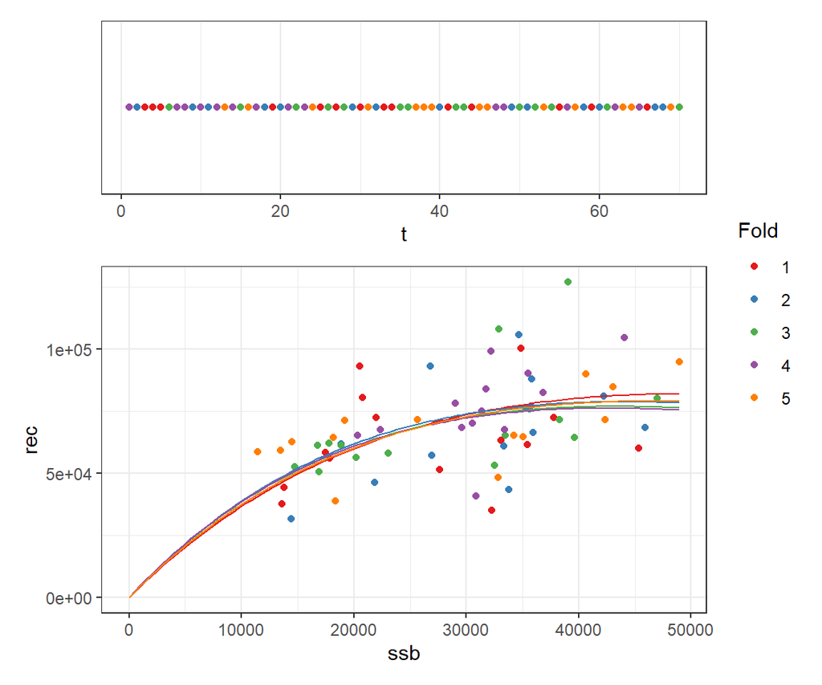

### 6.2.3 Influence of fold number on error

The number of folds chosen depends on several considerations; such as the variance in the data, number of samples, and computational cost. A low k (e.g. 5-fold) typically provides a good balance for the types of models that we have looked at. The larger amount of validation data (20%) provides a robust measure of prediction error, and the low number of folds is not computationally costly. That said, performing repeated k-fold cross validation (i.e. multiple permutations) will further reduce variability in error estimation.

The number of folds will influence the resulting metric of fit to the validation set. The more folds, the closer one gets to the error of the data, with a leave-one-out cross validation (*LOOCV*) being the least biased.

Note that model error (based on residuals) tends to underestimate the true prediction error because it is calculated on the same data used to train the model. This can lead to overfitting, where the model appears to perform better on the training data than it would on unseen data.

LOOCV provides a *nearly* unbiased estimate of the prediction error because each data point is excluded from the training set when its error is calculated. This does not mean that the underlying model couldn’t still suffer from overfitting.

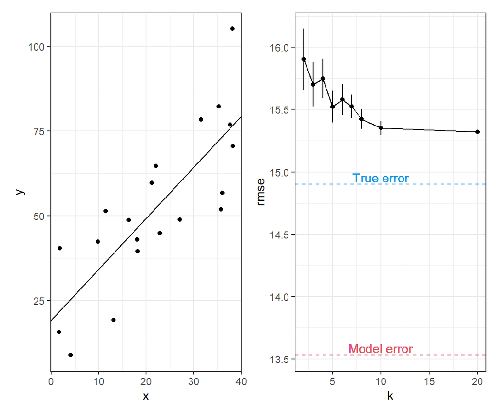

## 6.3 Flexible model selection

You can compare models of different structure as well. For example, AIC may not be comparable between models of different structure, e.g. mixed models with random effects. Comparison should be made using same folds (e.g. use of random seed). A variety of metrics could be used for the final model selection.

```r
res0 <- cvFun(model = fit0, nperm = 5, k = 5, seed = 1111)
res <- cvFun(model = fit, nperm = 5, k = 5, seed = 1111)

# mixed model with autoregressive term on time (t)
fmlatmp <- formula(fit)
fmlaMM <- as.formula(paste(c(deparse(fmlatmp), "+ ar1(t + 0 | 1)")))
fitMM <- glmmTMB(fmlaMM, data = dat, family = gaussian(link = "log"))
resMM <- cvFun(model = fitMM, nperm = 5, k = 5, seed = 1111)

cvStats0 <- with(res0, c(
  mse = mse(y = y, yhat = yhat),
  rmse = rmse(y = y, yhat = yhat),
  mape = mape(y = y, yhat = yhat),
  mdape = mdape(y = y, yhat = yhat),
  mae = mae(y = y, yhat = yhat)
))

cvStats <- with(res, c(
  mse = mse(y = y, yhat = yhat),
  rmse = rmse(y = y, yhat = yhat),
  mape = mape(y = y, yhat = yhat),
  mdape = mdape(y = y, yhat = yhat),
  mae = mae(y = y, yhat = yhat)
))

cvStatsMM <- with(resMM, c(
  mse = mse(y = y, yhat = yhat),
  rmse = rmse(y = y, yhat = yhat),
  mape = mape(y = y, yhat = yhat),
  mdape = mdape(y = y, yhat = yhat),
  mae = mae(y = y, yhat = yhat)
))

tmp <- cbind(cvStats0, cvStats, cvStatsMM)
tmp <- as.data.frame(t(apply(tmp, 1, FUN = function(x){
  paste0(format(x, scientific = TRUE, digits = 3),
    ifelse(x == min(x, na.rm = T), "*", " "))
})))

names(tmp) <- c("res0", "res", "resMM")
tmp
```

|  | res0 | res | resMM |
| --- | --- | --- | --- |
| mse | 2.58e+08 | 2.04e+08* | 1.62e+10 |
| rmse | 1.61e+04 | 1.43e+04* | 1.27e+05 |
| mape | 2.02e-01 | 1.78e-01* | 7.44e-01 |
| mdape | 1.67e-01 | 1.56e-01* | 5.53e-01 |
| mae | 1.32e+04 | 1.15e+04* | 5.04e+04 |

In this case, the addition of the random intercept with an autoregressive structure based on time (t) did not improve the model for any of the evaluated metrics.

# 7 Automated model selection with machine learning

Depending on the number of potential candidate models, as well as the complexity of the model fitting and cross validation procedures, model selection can become computationally costly. Thus, a brute force approach of evaluating all models with cross validation could be unrealistic.

In the example by Kühn, Taylor, and Kempf (2021), a large number of candidate covariates (n = 82) were chosen based on hypothesized biological mechanisms affecting recruitment of North Sea cod. These included time series signals extracted from environmental fields (e.g. principal components from temperature, salinity, and currents) at different temporal periods (and lags).

The approach used an efficient search algorithm called *non-dominated sorting genetic algorithm* (NSGA-II), combined with cross validation, to explore the large number of potential model configurations (n = 4.84e+24).

In the following example, we will explore a simplified version of the approach using a simpler implementation of a genetic algorithm.

## 7.1 Fitness function

```r
fitnessFun <- function(genes = NULL, data = NULL, nperm = 10, k = 5,
  ffSeed = 1, fitnessOnly = TRUE){

  fmla <- as.formula(
    paste(c("rec ~ offset(log(ssb)) + ssb", envvars[as.logical(genes)]), collapse = " + "),
    env = environment())
  fit <- glm(formula = fmla, data = data, family = gaussian(link = "log"))

  res <- cvFun(model = fit, nperm = nperm, k = k, seed = ffSeed)

  fitness <- -1 * mape(y = res$y, yhat = res$yhat) # to maximize, so reverse sign
  if(!fitnessOnly){
    byGroup <- res %>% group_by(perm) %>% summarise(mape = mape(y = y, yhat = yhat))
    se <- sd(byGroup$mape)/sqrt(nrow(byGroup))
  }
  if(fitnessOnly){
    out <- fitness
  }else{
    out <- list(fitness = fitness, byGroup = byGroup, se = se)
  }
  return(out)
}
```

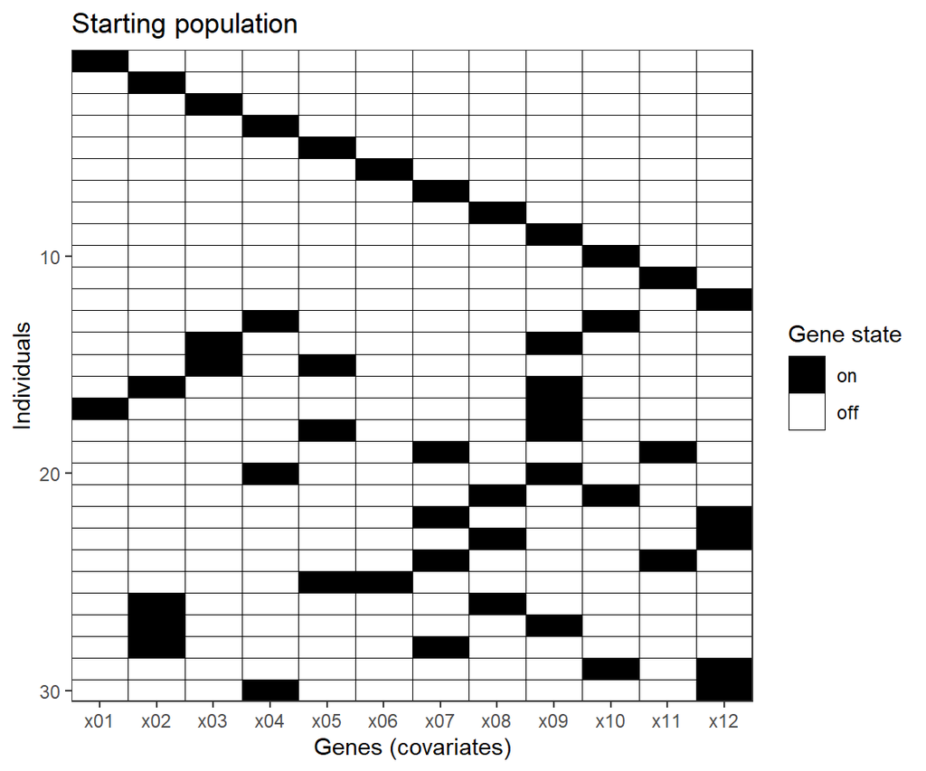

```r
popSize <- max(30, length(envvars)) # number of individuals

PARS <- seq(envvars)*0
startPop <- matrix(0, ncol = length(PARS), nrow = popSize)
diag(startPop[seq(PARS),]) <- 1
if(popSize > length(PARS)){
  hit <- seq(nrow(startPop))[-seq(PARS)]
  startPop[hit, ] <- t(apply(startPop[hit, ], 1,
    FUN = function(x){x[sample(seq(PARS), size = 2)] <- 1; x}))
}

tmp <- startPop
tmp[] <- c("off", "on")[c(tmp)+1]
df <- as.data.frame(tmp)
names(df) <- envvars
df$ind <- seq(nrow(df))

df_long <- df %>%
  pivot_longer(cols = -ind, names_to = "variable", values_to = "value")

ggplot(df_long, aes(x = variable, y = ind, fill = factor(value))) +
  geom_tile(colour = 1) +
  scale_fill_manual(name = "Gene state",
    values = c("black", "white"), breaks = c("on", "off")) +
  scale_y_reverse(expand = c(0, 0)) +
  scale_x_discrete(expand = c(0, 0)) +
  labs(x = "Genes (covariates)", y = "Individuals",
    title = "Starting population") +
  theme_bw()
```

Distribution of fitness for starting population

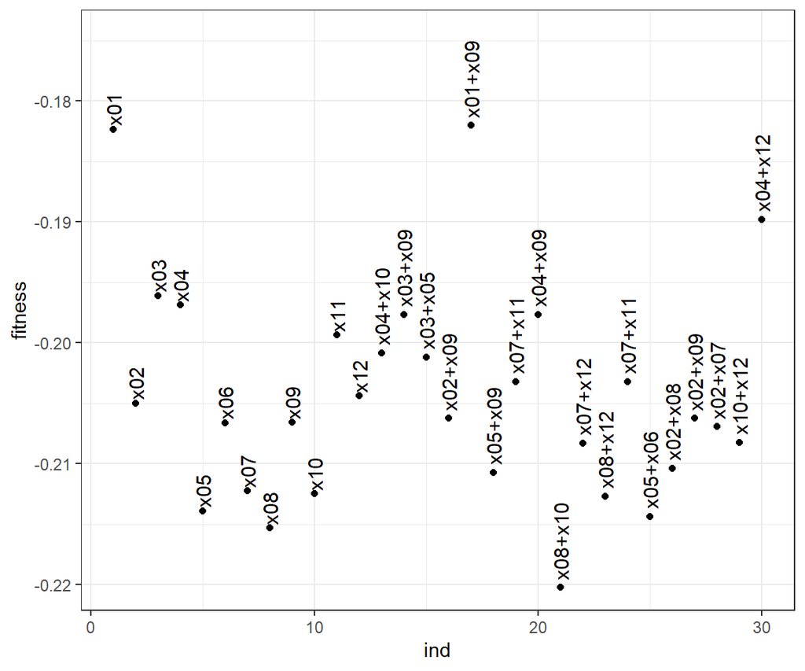

```r
tmp1 <- apply(startPop, 1, FUN = function(x){fitnessFun(x, data = dat)})
tmp2 <- apply(startPop, 1, FUN = function(x){paste(envvars[as.logical(x)], collapse = "+")})
tmp <- data.frame(ind = seq(tmp1), fitness = tmp1, covariates = tmp2)

ggplot(tmp) + aes(x = ind, y = fitness, label = covariates) +
  geom_point() +
  geom_text(angle = 90, hjust = -0.1, vjust = 0.5) +
  scale_y_continuous(expand = expansion(mult = c(0.05,0.25))) +
  theme_bw()
```

## 7.2 Genetic algorithm

Next, we will provide this starting population to a genetic algorithm (`GA::ga()`) of type “binary”, which will turn off/on the covariates, and test the resulting fitness. According to the [vignette of the GA package](https://cran.r-project.org/web/packages/GA/vignettes/GA.html):

> *Genetic algorithms (GAs) are stochastic search algorithms inspired by the basic principles of biological evolution and natural selection. GAs simulate the evolution of living organisms, where the fittest individuals dominate over the weaker ones, by mimicking the biological mechanisms of evolution, such as selection, crossover and mutation.*

Likewise, these aspects can be controlled by the `ga` function with secific arguments, e.g. the probability of gene crossover (`pcrossover`), the probability of mutation (`pmutation`), etc.

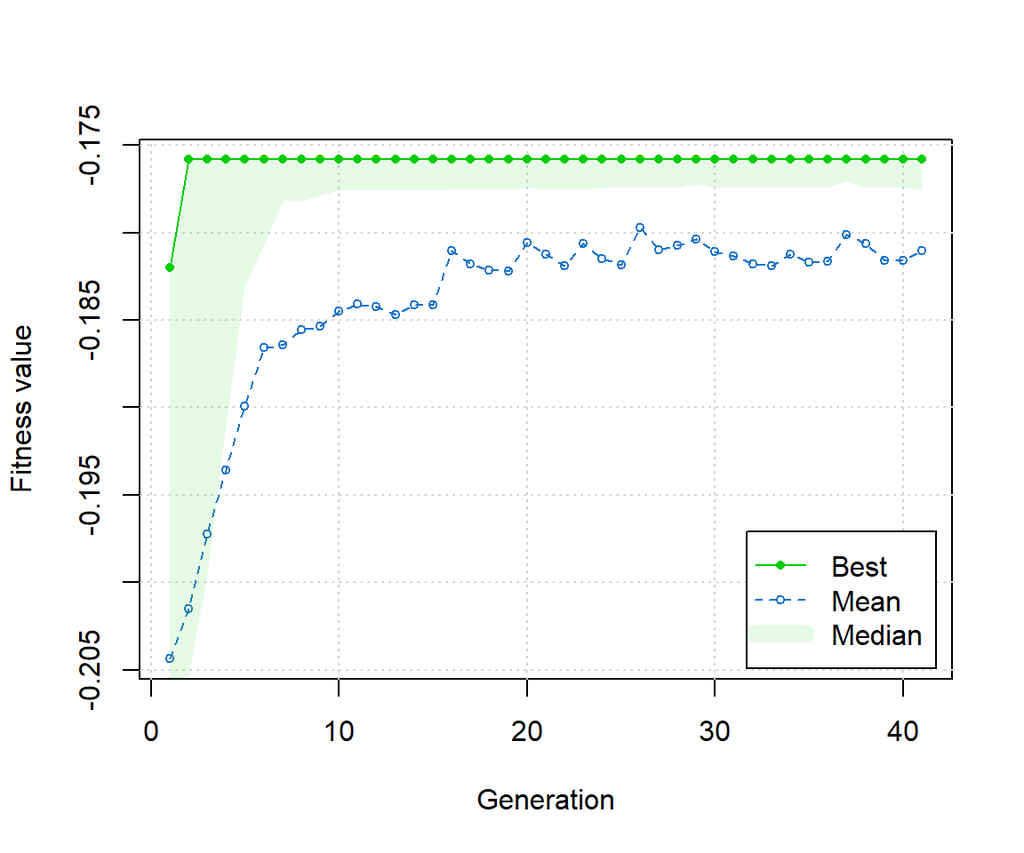

```r
# extra diagnostic data object to save all generations
postfit <- function(object, ...){
  pop <- as.data.frame(object@population)
  names(pop) <- paste0("par", seq(ncol(pop)))
  pop$fitness <- object@fitness
  pop$iter <- object@iter
  # update info
  if(!exists(".pop", envir = globalenv()))
    assign(".pop", NULL, envir = globalenv())
  .pop <- get(".pop", envir = globalenv())
  assign(".pop", rbind(.pop, pop), envir = globalenv())
  # output the input ga object (this is needed!)
  object
}

mfitnessFun <- memoise(fitnessFun) # a memoised version of the fitness function
.pop <- NULL # make sure diagnostic output is empty
t1 <- Sys.time()
ga.fit <- ga(
  type = "binary", # for covariate selection
  fitness = mfitnessFun, # fitness function
  nBits = length(envvars), # number of genes (covariates)
  suggestions = startPop, # starting population suggestions
  popSize = popSize, # population size
  pcrossover = 0.8, # probability of gene crossover
  pmutation = 0.2,  # probability of mutation
  elitism = popSize*0.1, # number of best fitness individuals to survive at each generation
  parallel = FALSE, # set to TRUE for parallel computing (memoisation may be less effective)
  maxiter = 100, # max number of generations
  run = 40, # the max number of generations without any improvement
  monitor = FALSE, # set to TRUE to monitor fitness evolution
  data = dat, # input data
  seed = 1, # for reproducibility
  postFitness = postfit # extra diagnostics function
)
t2 <- Sys.time()
# t2 - t1 # elapsed time
tmp <- forget(mfitnessFun) # to stop memoisation

plot(ga.fit) # plot fitness development
```

## 7.3 Pareto front

Rules of thumb (Tibshirani)

```r
.pop$nVar <- rowSums(.pop[,seq(envvars)])
.pop$fracVar <- .pop$nVar / length(envvars)
names(.pop)[seq(envvars)] <- envvars

# pareto front
agg <- aggregate(fitness ~ fracVar, data = .pop, FUN = max)

# determine standard error of pareto front models
parFront <- merge(x = agg, y = .pop, all.x = T)
parFront <- unique(parFront[,c(envvars, "nVar", "fracVar", "fitness")])
parFront <- parFront[order(parFront$nVar),]
parFront
```

|  | x01 | x02 | x03 | x04 | x05 | x06 | x07 | x08 | x09 | x10 | x11 | x12 | nVar | fracVar | fitness |
| --- | --- | --- | --- | --- | --- | --- | --- | --- | --- | --- | --- | --- | --- | --- | --- |
| 1 | 0 | 0 | 0 | 0 | 0 | 0 | 0 | 0 | 0 | 0 | 0 | 0 | 0 | 0.00000000 | -0.2072554 |
| 18 | 1 | 0 | 0 | 0 | 0 | 0 | 0 | 0 | 0 | 0 | 0 | 0 | 1 | 0.08333333 | -0.1823366 |
| 23 | 1 | 0 | 1 | 0 | 0 | 0 | 0 | 0 | 0 | 0 | 0 | 0 | 2 | 0.16666667 | -0.1770679 |
| 263 | 1 | 0 | 1 | 0 | 0 | 0 | 0 | 0 | 1 | 0 | 0 | 0 | 3 | 0.25000000 | -0.1758235 |
| 388 | 1 | 0 | 1 | 0 | 0 | 0 | 0 | 0 | 1 | 0 | 1 | 0 | 4 | 0.33333333 | -0.1774116 |
| 550 | 1 | 0 | 1 | 0 | 0 | 0 | 0 | 0 | 1 | 0 | 1 | 1 | 5 | 0.41666667 | -0.1770245 |
| 587 | 1 | 0 | 1 | 0 | 0 | 0 | 1 | 0 | 1 | 0 | 1 | 1 | 6 | 0.50000000 | -0.1798065 |
| 588 | 1 | 1 | 1 | 0 | 0 | 0 | 0 | 0 | 1 | 1 | 1 | 1 | 7 | 0.58333333 | -0.1836888 |

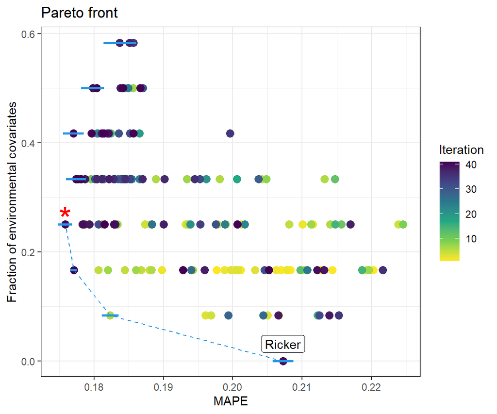

```r
parFront$se <- NaN
for(i in seq(nrow(parFront))){
  genes.i <- parFront[i,envvars]
  tmp <- fitnessFun(genes = genes.i, data = dat, nperm = 10, k = 5, ffSeed = 1, fitnessOnly = F)
  parFront$se[i] <- tmp$se
}


upr <- parFront$fitness + parFront$se
lwr <- parFront$fitness - parFront$se
mid <- parFront$fitness
# check if model fitness is greater than the upper bound of the simpler model
better <- mid > c(-Inf, upr[-length(lwr)])
parFront$best <- FALSE
hit <- max(which(better))
parFront$best[hit] <- TRUE

ggplot(.pop) + aes(x = -fitness, y = fracVar, color = iter) +
  geom_point(size = 3) +
  # scale_color_viridis_c(name = "Iteration", option = "magma", direction = -1) +
  scale_color_continuous(name = "Iteration", type = "viridis", direction = -1) +
  geom_path(data = parFront[better,], color = 4, linetype = 2) +
  geom_label(data = parFront[1,], color = 1, label = "Ricker",
    hjust = 0.5, vjust = -0.5) +
  geom_segment(data = parFront, aes(x = -fitness-se, xend = -fitness+se, y = fracVar, yend = fracVar),
    color = 4, linewidth = 1) +
  geom_text(data = subset(parFront, best), color = "red", label = "*", size = 10, vjust = 0.25) +
  labs(x = "MAPE", y = "Fraction of environmental covariates", title = "Pareto front") +
  theme_bw()
```

```r
parFront
```

|  | x01 | x02 | x03 | x04 | x05 | x06 | x07 | x08 | x09 | x10 | x11 | x12 | nVar | fracVar | fitness | se | best |
| --- | --- | --- | --- | --- | --- | --- | --- | --- | --- | --- | --- | --- | --- | --- | --- | --- | --- |
| 1 | 0 | 0 | 0 | 0 | 0 | 0 | 0 | 0 | 0 | 0 | 0 | 0 | 0 | 0.00000000 | -0.2072554 | 0.0014959397 | FALSE |
| 18 | 1 | 0 | 0 | 0 | 0 | 0 | 0 | 0 | 0 | 0 | 0 | 0 | 1 | 0.08333333 | -0.1823366 | 0.0011985004 | FALSE |
| 23 | 1 | 0 | 1 | 0 | 0 | 0 | 0 | 0 | 0 | 0 | 0 | 0 | 2 | 0.16666667 | -0.1770679 | 0.0005376845 | FALSE |
| 263 | 1 | 0 | 1 | 0 | 0 | 0 | 0 | 0 | 1 | 0 | 0 | 0 | 3 | 0.25000000 | -0.1758235 | 0.0009978026 | TRUE |
| 388 | 1 | 0 | 1 | 0 | 0 | 0 | 0 | 0 | 1 | 0 | 1 | 0 | 4 | 0.33333333 | -0.1774116 | 0.0014459393 | FALSE |
| 550 | 1 | 0 | 1 | 0 | 0 | 0 | 0 | 0 | 1 | 0 | 1 | 1 | 5 | 0.41666667 | -0.1770245 | 0.0014919452 | FALSE |
| 587 | 1 | 0 | 1 | 0 | 0 | 0 | 1 | 0 | 1 | 0 | 1 | 1 | 6 | 0.50000000 | -0.1798065 | 0.0016385288 | FALSE |
| 588 | 1 | 1 | 1 | 0 | 0 | 0 | 0 | 0 | 1 | 1 | 1 | 1 | 7 | 0.58333333 | -0.1836888 | 0.0023353466 | FALSE |

**Results:**

- Best model is rec ~ offset(log(ssb)) + ssb + x01 + x03 + x09.
- We evaluated a population of 30 individuals for 41 generations, totaling 1230 fitness evaluations.
- Memoisation evaluated 163 unique models, saving us 87% of fitness evaluations.
- Only 163 model configurations out of a total possible 4095 were evaluated (4%).

## 7.4 Flavor 2: Temporal blocking

To address potential residual autocorrelation

There is autocorrelation evident in the response variable recruitment

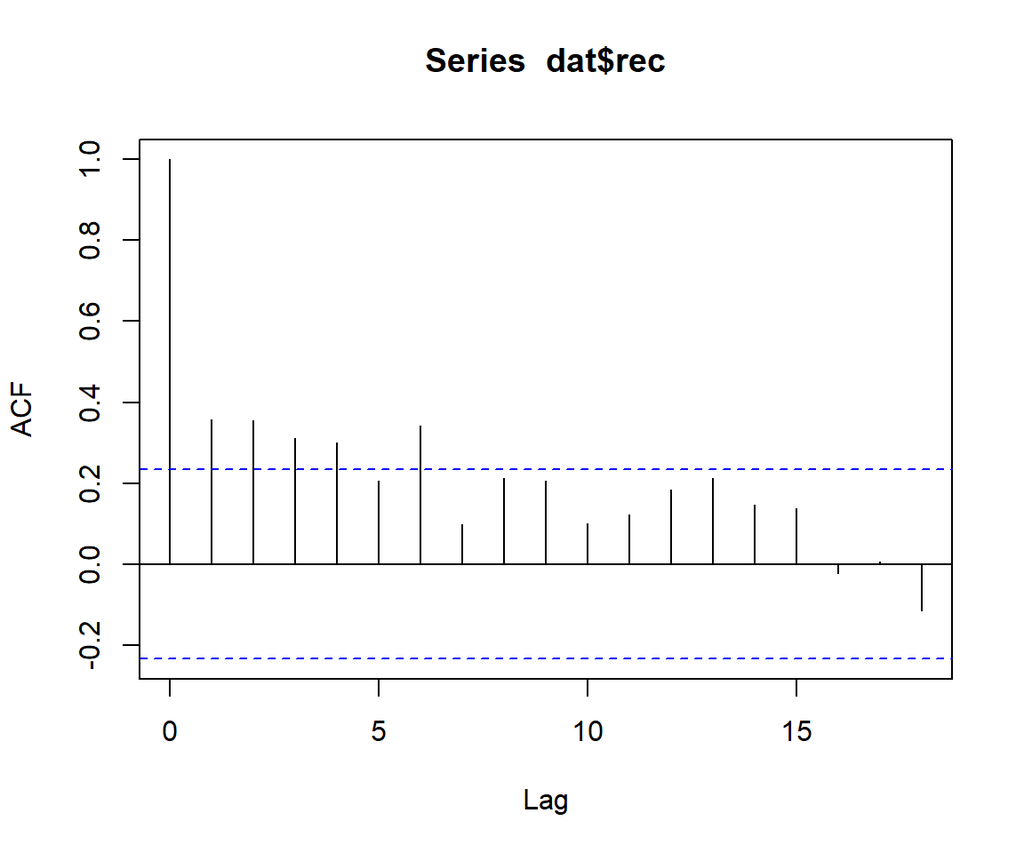

```r
acf(dat$rec)
```

But this is largely explained by the covariates considered (e.g. fluctuations in SSB)

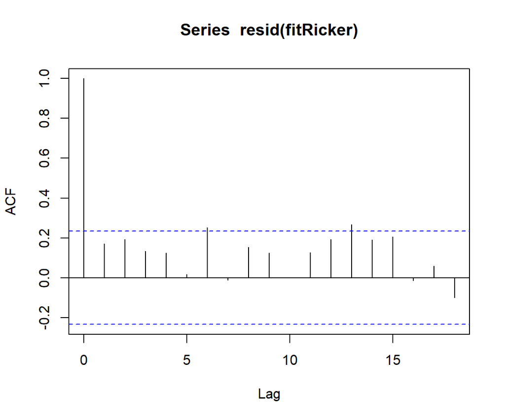

[figure not shown]

```r
fitRicker <- glm(rec ~ offset(log(ssb)) + ssb, data = dat, gaussian(link = "log"))
acf(resid(fitRicker))
```

## 7.5 Flavor 3: Hindcast preformance

When future prediction is the focus, you may want to select the validation data more carefully to prevent the model from “*seeing*” the future, which could potentially bias results. One strategy is to again fit the model to the *training* data set, but have two holdout sets of future data: 1. the *validation* set, used for model selection, and 2. the *testing* set for evaluating prediction performance.

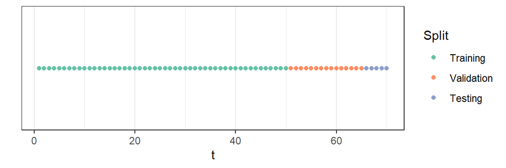

This can also be done in a rolling prediction manner, where the length of the training, validation, and testing sets are defined, and the starting data point can vary through time, within the limits allowed by these set lengths.

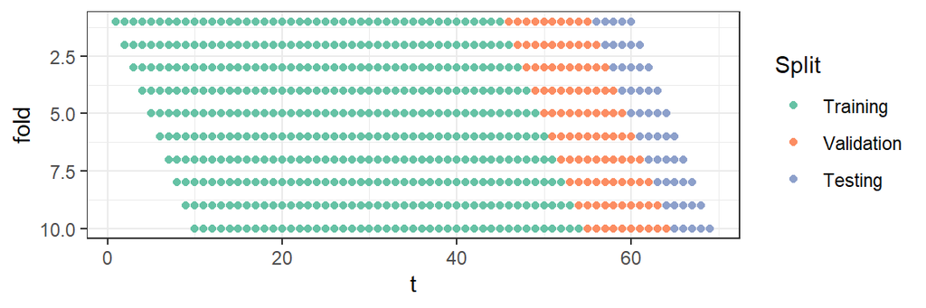

Finally, it may be useful to compare the prediction performance to some *naive* prediction, such as a men of recent values. The *MASE* metric is of particular use for this kind of forecast comparison.

In our example, since no strong autocorrelation was detected, lets try a k-fold approach for the model selection, leaving out the final 5 years of the data for MASE evaluation versus a naive model.

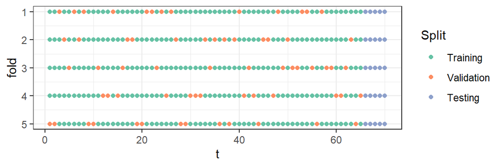

```r
# split data into training/validation & testing
nTest <- 5
datTrainValid <- subset(dat, t <= max(t)-nTest)
datTest <- subset(dat, t > max(t)-nTest)

mfitnessFun <- memoise(fitnessFun) # a memoised version of the fitness function
.pop <- NULL # make sure diagnostic output is empty
t1 <- Sys.time()
ga.fit <- ga(
  type = "binary", # for covariate selection
  fitness = mfitnessFun, # fitness function
  nBits = length(envvars), # number of genes (covariates)
  suggestions = startPop, # starting population suggestions
  popSize = popSize, # population size
  pcrossover = 0.8, # probability of gene crossover
  pmutation = 0.2,  # probability of mutation
  elitism = popSize*0.1, # number of best fitness individuals to survive at each generation
  parallel = FALSE, # set to TRUE for parallel computing (memoisation may be less effective)
  maxiter = 100, # max number of generations
  run = 40, # the max number of generations without any improvement
  monitor = FALSE, # set to TRUE to monitor fitness evolution
  data = datTrainValid, # input data *** ONLY TRAIN/VALID ***
  seed = 1, # for reproducibility
  postFitness = postfit # extra diagnostics function
)
t2 <- Sys.time()
# t2 - t1 # elapsed time
tmp <- forget(mfitnessFun) # to stop memoisation

.pop$nVar <- rowSums(.pop[,seq(envvars)])
.pop$fracVar <- .pop$nVar / length(envvars)
names(.pop)[seq(envvars)] <- envvars

# pareto front
agg <- aggregate(fitness ~ fracVar, data = .pop, FUN = max)

# determine standard error of pareto front models
parFront <- merge(x = agg, y = .pop, all.x = T)
parFront <- unique(parFront[,c(envvars, "nVar", "fracVar", "fitness")])
parFront <- parFront[order(parFront$nVar),]
parFront
```

|  | x01 | x02 | x03 | x04 | x05 | x06 | x07 | x08 | x09 | x10 | x11 | x12 | nVar | fracVar | fitness |
| --- | --- | --- | --- | --- | --- | --- | --- | --- | --- | --- | --- | --- | --- | --- | --- |
| 1 | 0 | 0 | 0 | 0 | 0 | 0 | 0 | 0 | 0 | 0 | 0 | 0 | 0 | 0.00000000 | -0.2160559 |
| 24 | 1 | 0 | 0 | 0 | 0 | 0 | 0 | 0 | 0 | 0 | 0 | 0 | 1 | 0.08333333 | -0.1865681 |
| 659 | 1 | 0 | 0 | 0 | 0 | 0 | 0 | 0 | 0 | 0 | 0 | 1 | 2 | 0.16666667 | -0.1870686 |
| 718 | 1 | 0 | 0 | 1 | 0 | 0 | 0 | 0 | 0 | 0 | 0 | 1 | 3 | 0.25000000 | -0.1877566 |
| 722 | 1 | 0 | 0 | 1 | 0 | 0 | 0 | 0 | 0 | 1 | 0 | 1 | 4 | 0.33333333 | -0.1895742 |

```r
parFront$se <- NaN
for(i in seq(nrow(parFront))){
  genes.i <- parFront[i,envvars]
  tmp <- fitnessFun(genes = genes.i, data = dat, nperm = 10, k = 5, ffSeed = 1, fitnessOnly = F)
  parFront$se[i] <- tmp$se
}


upr <- parFront$fitness + parFront$se
lwr <- parFront$fitness - parFront$se
mid <- parFront$fitness
# check if model fitness is greater than the upper bound of the simpler model
better <- mid > c(-Inf, upr[-length(lwr)])
parFront$best <- FALSE
hit <- max(which(better))
parFront$best[hit] <- TRUE
best <- subset(parFront, best)[envvars]
best <- paste(c(fixed_variables, names(best)[best == 1]), collapse = " + ")
```

The best model is rec ~ offset(log(ssb)) + ssb + x01, which we will then fit again to the full training/validation data, and predict the testing holdout. The naive model prediction will be the geometric mean of recruitment from the last 10 years.

```r
# refit best model
fmla <- best
fitBest <- update(fit, data = datTrainValid,
  formula = as.formula(fmla, env = environment()))
yhat <- predict(fitBest, newdata = datTest, type = "response")

# compare to geometric mean
yhat_naive_gm <- rep(exp(mean(log(tail(datTrainValid$rec, 10)))), nrow(datTest))
MASE_gm <- mase(y = datTest$rec, yhat = yhat, yhat_naive = yhat_naive_gm)

# compare to non-env Ricker
fmla <- "rec ~ ssb + offset(log(ssb))"
fitRicker <- update(fit, data = datTrainValid,
  formula = as.formula(fmla, env = environment()))
yhat_naive_ri <- predict(fitRicker, newdata = datTest, type = "response")
MASE_ri <- mase(y = datTest$rec, yhat = yhat, yhat_naive = yhat_naive_ri)
```

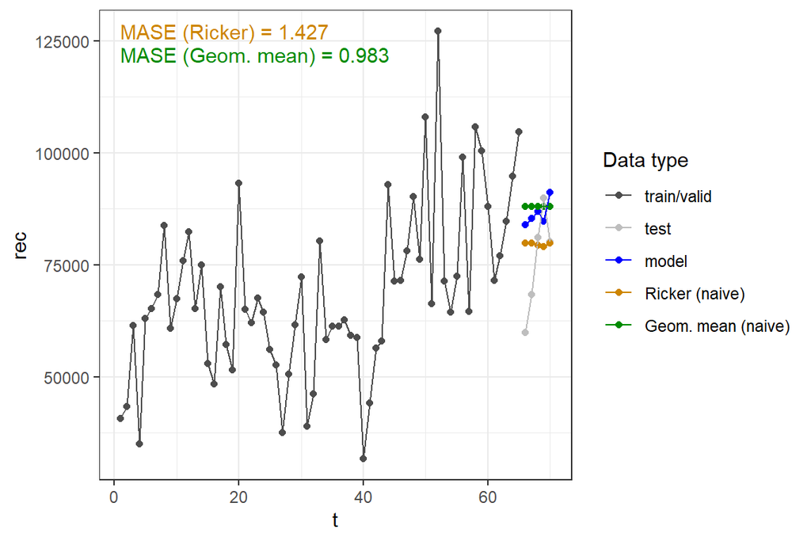

Short- vs long-term performance (MSE scenario vs STF)

# 8 Further considerations

- Predicting outside the observed range
  - Mechanistic-based models may be more constrained when new covariate values beyond the historical range are used for prediction
- Detrending data?
- NSGA-II

# 9 Software Versions

- R version 4.4.0 (2024-04-24 ucrt)
- corrplot: 0.92
- doRNG: 1.8.6
- dplyr: 1.1.4
- forecast: 8.23.0
- GA: 3.2.4
- ggplot2: 3.5.1
- glmmTMB: 1.1.9
- knitr: 1.48
- memoise: 2.0.1
- MuMIn: 1.48.4
- parallel: 4.4.0
- patchwork: 1.2.0.9000
- tidyr: 1.3.1
- **Compiled**: 2024-Nov-19

# 10 Author

**Marc Taylor**. Thünen Institute of Sea Fisheries, Marine Living Resources Unit, Herwigstraße 31, 27572 Bremerhaven, Germany. https://www.thuenen.de/en/sf/

# References

Akimova, Anna, Ismael Núñez-Riboni, Alexander Kempf, and Marc H. Taylor. 2016. “Spatially-Resolved Influence of Temperature and Salinity on Stock and Recruitment Variability of Commercially Important Fishes in the North Sea.” *PLoS ONE* 11 (9): 1–25. https://doi.org/10.1371/journal.pone.0161917.

Iles, T. C. 1994. “A Review of Stock-Recruitment Relationships with Reference to Flatfish Populations.” *Netherlands Journal of Sea Research* 32 (3): 399–420. http://www.sciencedirect.com/science/article/pii/0077757994900175.

Iles, T. C., and R. J. H. Beverton. 1998. “Stock, Recruitment and Moderating Processes in Flatfish.” *Journal of Sea Research*, Proceedings of the Third International Symposium on Flatfish Ecology, Part II, 39 (1–2): 41–55. https://doi.org/10.1016/S1385-1101(97)00022-1.

Kühn, Bernhard, Marc H. Taylor, and Alex Kempf. 2021. “Using Machine Learning to Link Spatiotemporal Information to Biological Processes in the Ocean: A Case Study for North Sea Cod Recruitment.” *Marine Ecology Progress Series* 664 (April): 1–22. https://doi.org/10.3354/meps13689.

Levi, Dino, M. G. Andreoli, A. Bonanno, Fabio Fiorentino, G. Garofalo, S. Mazzola, Giacomo Norrito, et al. 2003. “Embedding Sea Surface Temperature Anomalies into the Stock Recruitment Relationship of Red Mullet (Mullus Barbatus L. 1758) in the Strait of Sicily.” *Scientia Marina* 67 (S1): 259–68. http://scientiamarina.revistas.csic.es/index.php/scientiamarina/article/viewArticle/525.